# Poland Parliamet Report

Ruzza Tomas, Ippolito Fedra, De Luca Simone

1/25/2021

### Research question

Do Polish citizens have equal trust in their own Parliament and the European Parliament? We test the data from European Social Survey (round 9) looking for evidences. We think that the levels are different in favour of Polish Parliament.

### Distribution of Trust in Polish Parliament

Those are the results of the distibution:

| vars | n |
| --- | --- |
| 0 | 162 |
| 1 | 67 |
| 2 | 109 |
| 3 | 143 |
| 4 | 119 |
| 5 | 240 |
| 6 | 95 |
| 7 | 88 |
| 8 | 44 |
| 9 | 14 |

[output cut: 1 more lines]

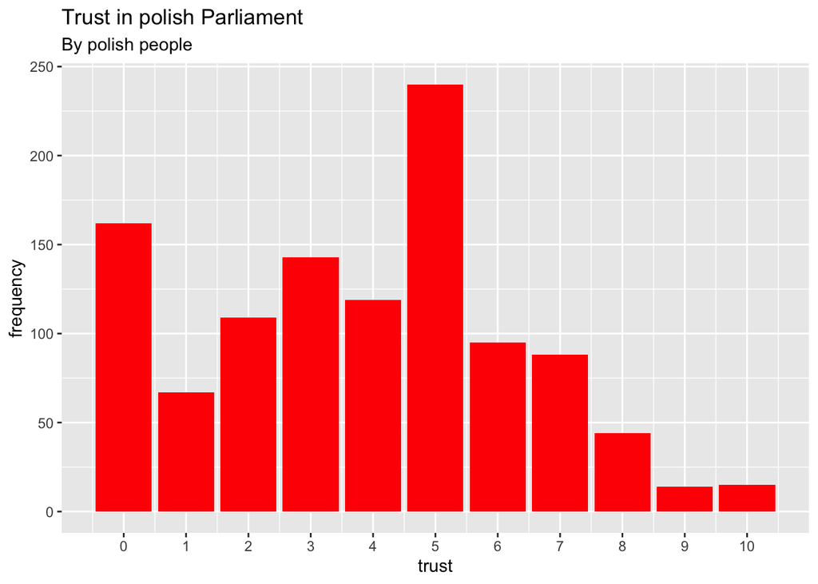

Trust appears to be not particularly strong, in fact more than half of the citizens have expressed a level of satisfaction lower than 5/10. In particular, there are only 15 people totally in trust with their own Parliament.

### Distribution of Trust in European Parliament

Those are the results of the distibution:

```r
count(poland_sub_clean, vars = trstep)
```

| vars | n |
| --- | --- |
| 0 | 91 |
| 1 | 39 |
| 2 | 77 |
| 3 | 95 |
| 4 | 123 |
| 5 | 252 |
| 6 | 118 |
| 7 | 126 |
| 8 | 89 |
| 9 | 25 |

[output cut: 1 more lines]

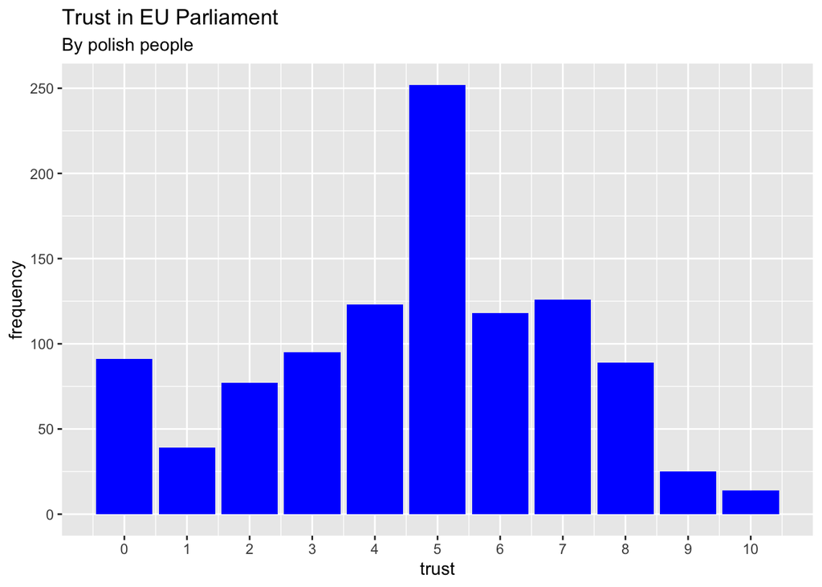

```r
ggplot(data = poland_sub_clean, aes(x = trstep)) +
  geom_bar(fill = "blue")+
  labs(title = "Trust in EU Parliament",
       subtitle = "By polish people",
       x = "trust", y = "frequency") +
  scale_x_continuous(breaks = seq(0, 10))
```

The results appear to be very similar, therefore we have decided to make a comparison of the means, and this is the reason why we haven’t categorized the values of the variables. #Comparing the means

```r
poland_sub_clean %>%
  summarize_if(is.numeric, ~mean(., na.rm = T))
```

| trstprl | trstep |
| --- | --- |
| 3.886756 | 4.668255 |

Surprisingly we have found that there is more trust into the European Parliament than in the Polish one.

### Linear Model

A linear model could be useful to verify whether there is a correlation between the variables:

```r
summary(linear_analysis)
```

```
##
## Call:
## lm(formula = trstprl ~ trstep, data = poland_sub_clean)
##
## Residuals:
##     Min      1Q  Median      3Q     Max
## -4.8046 -1.7714  0.2286  1.5398  6.9174
##
## Coefficients:
##             Estimate Std. Error t value Pr(>|t|)
## (Intercept)  3.08261    0.16492   18.69  < 2e-16 ***
## trstep       0.17220    0.03137    5.49 5.06e-08 ***
## ---
## Signif. codes:  0 '***' 0.001 '**' 0.01 '*' 0.05 '.' 0.1 ' ' 1
##
## Residual standard error: 2.446 on 1040 degrees of freedom
##   (7 observations deleted due to missingness)
## Multiple R-squared:  0.02816,    Adjusted R-squared:  0.02723
## F-statistic: 30.14 on 1 and 1040 DF,  p-value: 5.063e-08
```

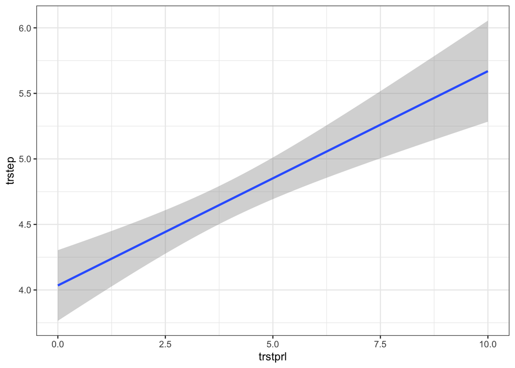

With an r squared of 0.03 we cannot say that a correlation does not exist, but if it does, there is a weak positive linear association as the plot suggests.

### Conclusions

Our starting hypothesis has been revealed as false, in fact Polish citizens have an higher trust in European Parliament then in their own one. However, it exists a weak relationship between the variables analyzed that suggest that the more citizens trust Polish Parliament, the more trust the European one.